# Ststistcal Inference of Exponentials

nselvak

8/24/2020

# Overview

What will be reported is answers to the questions given and the steps taken to answer the questions given. Mainly, it will be some usual data preprocessing and then the actual simulations and the results

## Instructions

1. Show the sample mean and compare it to the theoretical mean of the distribution.
2. Show how variable the sample is (via variance) and compare it to the theoretical variance of the distribution.
3. Show that the distribution is approximately normal.

## Loading Libraries

```r
library(tidyverse)
```

## Task

```r
# set seed for reproducability
set.seed(84)

# set lambda to 0.2
lambda <- 0.2

# 40 samples
n <- 40

# 1000 simulations
sims <- 1000

# simulate
sim_expo <- replicate(sims, rexp(n, lambda))

# calculate mean of exponentials
mean_expo <- apply(sim_expo, 2, mean)
```

## Question 1

Show where the distribution is centered at and compare it to the theoretical center of the distribution.

```r
# analytical mean
analytical_mean <- mean(mean_expo)
analytical_mean
```

```
## [1] 5.02034
```

```r
# Theoratical mean
theory_mean <- 1/lambda
theory_mean
```

```
## [1] 5
```

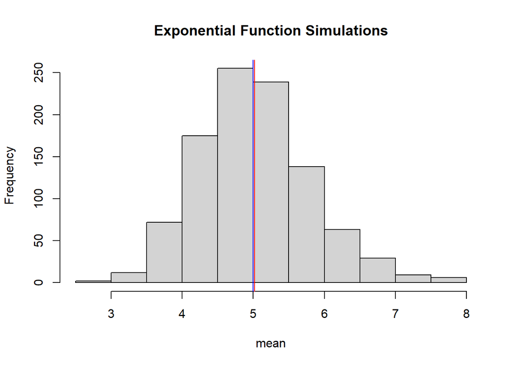

```r
# visualization

hist(mean_expo,
     xlab = "mean",
     main = "Exponential Function Simulations")
abline(v = analytical_mean, col = "red")
abline(v = theory_mean, col = "blue")
```

Analytics mean is 5.0203397 and theoretical mean 5. Center of distribution for average of 40 exponentials is very close to the theoretical center of the distribution.

## Question 2

Show how variable it is and compare it to the theoretical variance of the distribution..

```r
# standard deviation of distribution
sd_dist <- sd(mean_expo)
sd_dist
```

```
## [1] 0.7812229
```

```r
# standard deviation from analytical expression
sd_theory <- (1/lambda)/sqrt(n)
sd_theory
```

```
## [1] 0.7905694
```

```r
# variance of distribution
var_dist <- sd_dist^2
var_dist
```

```
## [1] 0.6103091
```

```r
# variance from analytical expression
var_theory <- ((1/lambda)*(1/sqrt(n)))^2
var_theory
```

```
## [1] 0.625
```

## Question 3

Show that the distribution is approximately normal.

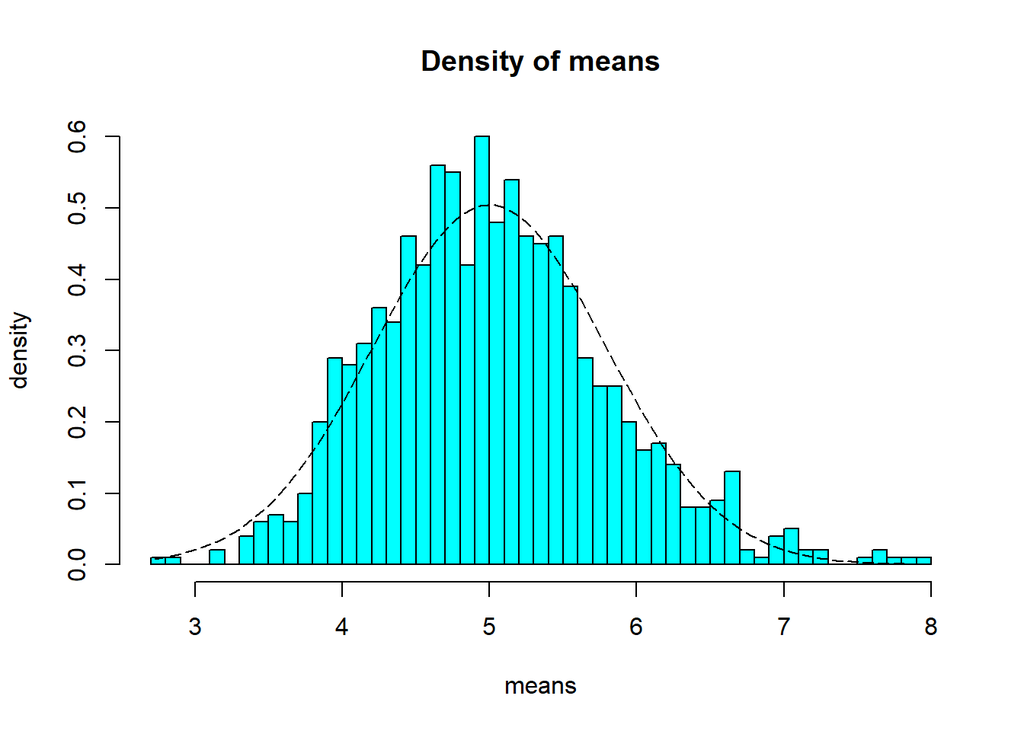

```r
xfit <- seq(min(mean_expo), max(mean_expo), length=100)
yfit <- dnorm(xfit, mean=1/lambda, sd=(1/lambda/sqrt(n)))

hist(mean_expo, breaks=n, prob=T, col="cyan",
     xlab = "means",
     ylab="density",
     main="Density of means")
lines(xfit, yfit, pch=22, col="black", lty=5)
```

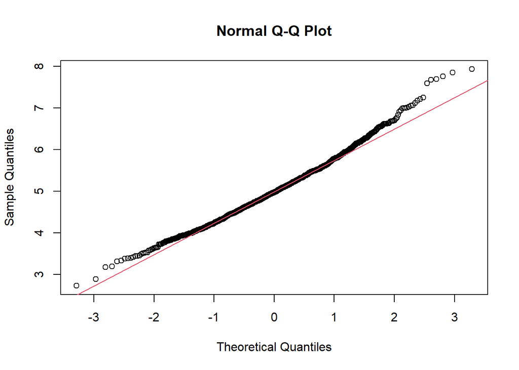

```r
# compare the distribution of averages of 40 exponentials to a normal distribution
qqnorm(mean_expo)
qqline(mean_expo, col = 2)
```

Quoting the central limit theorem (CLT), the distribution of averages of 40 exponentials is very close to a normal distribution.